# Assigment - Naive Bayes DIY

Niels Eenink - Author

Chantal Lenz - Reviewer

15 oktober, 2021

```r
#install.packages("tidyverse")
#install.packages("tm")
#install.packages("caret")
#install.packages("wordcloud")
#install.packages("e1071")

library(tidyverse)
library(tm)
library(caret)
library(wordcloud)
library(e1071)
```

Choose a suitable dataset from [this](https://github.com/HAN-M3DM-Data-Mining/assignments/tree/master/datasets) folder and train your own Naive Bayes model. Follow all the steps from the CRISP-DM model.

## Business Understanding

There are a lot of organisations in the world which publish news articles. Some of those organisations publish so called “fake news”. To help filter out the fake from the non-fake news a classifier called naive bayes helps determine reliable and unreliable sources.

## Data Understanding

We received a big/ bulky data set which contains a lot of information, such as: id, title, author, text and label. A lot of this data is not relevant to us in this case, so removing the non relevant will not only create a simpler and clearer data set, it will also make the processing of the data a lot faster.

```r
#First we load in the data.
FN_data <- "./NB-fakenews.csv"
fullDF <- read.csv(FN_data, encoding = "UTF-8")

#After the data is loaded, we can remove the unwanted columns. The dataframe with all the data is called "fullDF" (DF=DataFrame).
#The following command makes a new dataframe without the columns we want to exclude (the "-" means we don't want the column in the new dataframe). Let's call this dataframe "cleanDF", because we "cleaned" it by removing the unwanted/unused data.
cleanDF <- fullDF[c(-1, -3, -4)] %>%
  na.omit
head(cleanDF)
```

|  | title | label |
| --- | --- | --- |
| 1 | House Dem Aide: We Didn’t Even See Comey’s Letter Until Jason Chaffetz Tweeted It | 1 |
| 2 | FLYNN: Hillary Clinton, Big Woman on Campus - Breitbart | 0 |
| 3 | Why the Truth Might Get You Fired | 1 |
| 4 | 15 Civilians Killed In Single US Airstrike Have Been Identified | 1 |
| 5 | Iranian woman jailed for fictional unpublished story about woman stoned to death for adultery | 1 |
| 6 | Jackie Mason: Hollywood Would Love Trump if He Bombed North Korea over Lack of Trans Bathrooms (Exclusive Video) - Breitbart | 0 |

So now we that we decreased the size of the dataframe by three variables we can look into the information we have to analyse.

The first thing I noticed is the naming of the column that shows if the article is (un)reliable, “label”. I would like a more explanatory name, like “reliability”.

```r
#Change the column name from "label" to "reliability".
colnames(cleanDF)[2] <- "reliability"
```

So now it says reliability with a bunch of zero’s and one’s… To make it a bit more understandable for the non coding savvy people among us, let’s change this into “reliable” and “unreliable”.

```r
#Change the data inside the column "reliability" from zero's and one's into "reliable" and "unreliable"
cleanDF$reliability <- factor(cleanDF$reliability, levels = c("0", "1"), labels = c("reliable", "unreliable"))

#Convert class type to factor
cleanDF$reliability <- cleanDF$reliability %>%
  factor %>%
  relevel("reliable")
class(cleanDF$reliability)
```

```
[1] "factor"
```

```
factor
```

```r
#Switch title and reliability columns
col_order <- c("reliability", "title")
cleanDF <- cleanDF[, col_order]
```

Now that we have a clean data set with understandable data let’s make a wordcloud.

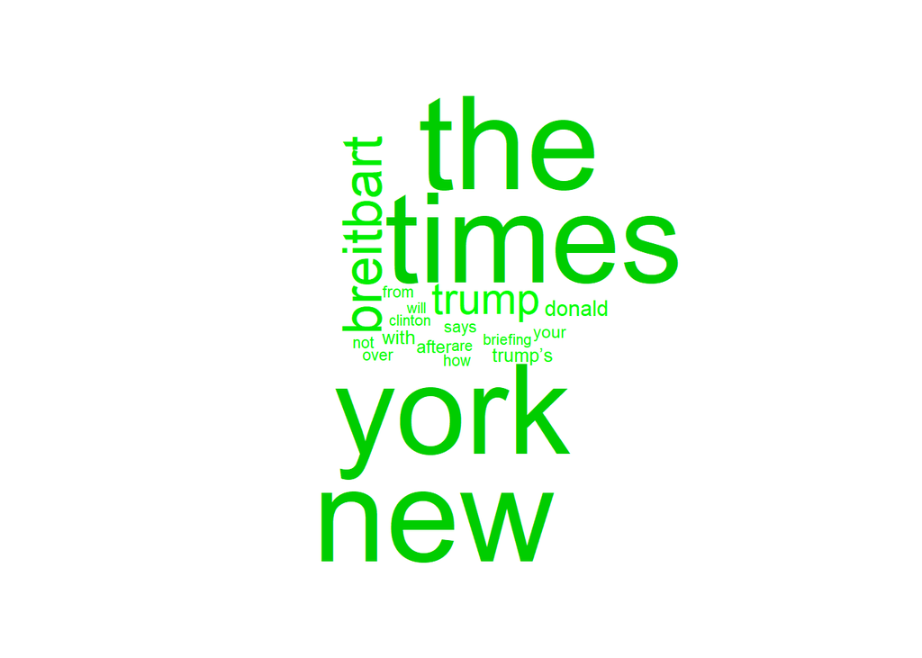

```r
#First we have to split the data set into two, one has all the titles with where the column "reliability" is "reliable".
reliable <- cleanDF %>% filter(reliability == "reliable")
#And the other has all the titles where the column "reliability" is "unreliable".
unreliable <- cleanDF %>% filter(reliability == "unreliable")

#When making a wordcloud the word that occur the most will be biggest
#Let's make the reliable wordcloud green (positive).
wordcloud(reliable$title, min.freq = 2, max.words = 20, scale = c(6, 0.5), colors= c("green1","green2","green3"))
```

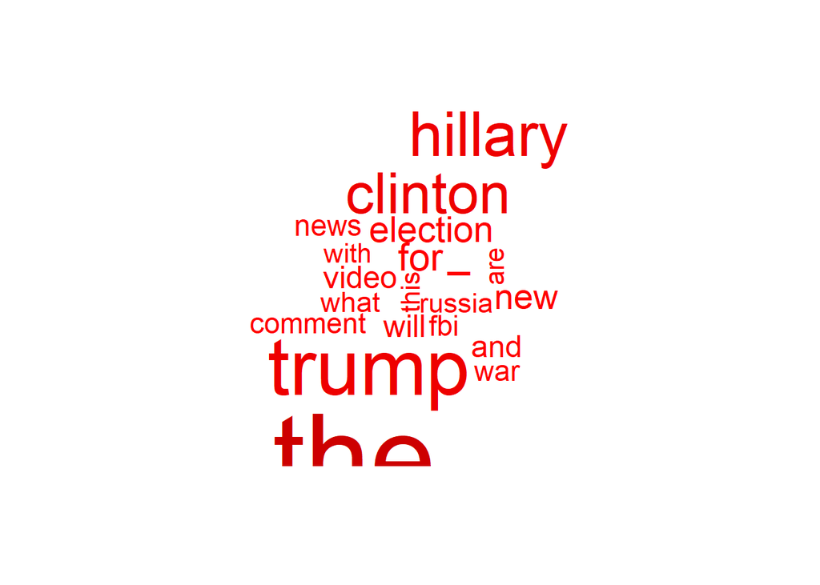

```r
#And the unreliable wordcloud red (negative).
wordcloud(unreliable$title, min.freq = 2, max.words = 20, scale = c(6, 0.5), colors= c("red1","red2","red3"))
```

## Data Preparation

The first step we need to take is creating a so called Corpus, which refers to a collection of text documents.

```r
#Convert text into Corpus
fullCorpus <- Corpus(VectorSource(fullDF$title))
inspect(fullCorpus[1:3])
```

```
<<SimpleCorpus>>
Metadata:  corpus specific: 1, document level (indexed): 0
Content:  documents: 3

[1] House Dem Aide: We Didn’t Even See Comey’s Letter Until Jason Chaffetz Tweeted It
[2] FLYNN: Hillary Clinton, Big Woman on Campus - Breitbart
[3] Why the Truth Might Get You Fired
```

Now that we have converted the text to Corpus we need to remove any capital letters, because R will see “Word” and “word” as different words, this is something we don’t want. Numbers are also not wanted.

```r
#Convert all text into lowercase and remove numbers.
cleanCorpus <- fullCorpus %>%
  tm_map(tolower) %>%
  tm_map(removeNumbers)
```

Because we want the program to run as fast as possible words like “and”, “the”, “or”, etc. are removed from the data set. Note that this doesn’t affect the outcome because reliable and unreliable sources use these so called stop words. We also remove any punctuation.

```r
#Note that the removeWords function needs an extra argument. This argument is left empty, but can contain a vector with the words you define as stop words.
cleanCorpus <- cleanCorpus %>%
  tm_map(removeWords, stopwords()) %>%
  tm_map(removePunctuation)
```

By removing the stop words there are sometimes two spaces between words where the stop word used to be. This is called a whitespace and this is not wanted. So let’s remove them.

```r
#Remove Whitespaces
cleanCorpus <- cleanCorpus %>%
    tm_map(stripWhitespace)
```

Let’s see what we changed!

```r
#Compare fullCorpus with cleanCorpus
tibble(Full = fullCorpus$content[1:3], Clean = cleanCorpus$content[1:3])
```

| Full | Clean |
| --- | --- |
| House Dem Aide: We Didn’t Even See Comey’s Letter Until Jason Chaffetz Tweeted It | house dem aide didn’t even see comey’s letter jason chaffetz tweeted |
| FLYNN: Hillary Clinton, Big Woman on Campus - Breitbart | flynn hillary clinton big woman campus breitbart |
| Why the Truth Might Get You Fired | truth might get fired |

Now that we have clean titles we can convert the cleanCorpus dataframe into a matrix. By converting the cleanCorpus dataframe into a matrix each word will get its own column. Each row is a title and the cells of the matrix contains the wordcount.

```r
#Convert cleanCorpus dataframe into a DTM (DocumentTermMatrix).
cleanDTM <- cleanCorpus %>% DocumentTermMatrix
inspect(cleanDTM)
```

```
<<DocumentTermMatrix (documents: 20800, terms: 27816)>>
Non-/sparse entries: 172563/578400237
Sparsity           : 100%
Maximal term length: 62
Weighting          : term frequency (tf)
Sample             :
       Terms
Docs    ’ breitbart clinton donald hillary new times trump will york
  1174  0         0       0      0       0   0     0     0    0    0
  16230 0         0       0      0       0   0     0     0    0    0
  18042 0         0       0      0       0   0     0     0    0    0
  18494 0         0       0      0       0   0     0     0    0    0
  19953 0         0       0      0       0   0     0     0    0    0
  2096  0         0       0      0       0   1     0     0    1    0
  318   0         0       0      0       0   0     0     0    0    0
  3398  0         0       0      0       0   0     0     0    0    0
  5774  0         0       0      0       0   0     0     0    0    0
  8999  0         0       0      0       0   0     0     0    0    0
```

So now we have a matrix in which we can see how many times a word occurs in reliable and unreliable articles. You may think it’s now time to start modeling, but there is still something we need to do.

When a computer program makes a decision it does it by looking up past instances where the situation occurred, for example: When the word “California” occurs in a title, does this make the article reliable or not? What if it is in combination with “man”? For a program to make such decisions it needs to be trained. So it needs data in which humans already made the decisions if a article is reliable or not. Luckily for us, we happen to have exactly that!

So let’s split our data in two parts. Training- and test data. When giving a program only a small amount of data problems like false positive and false positive can occur, so let’s make sure this doesn’t happen.

Let’s split the data 80/20 (training/test).

```r
#Split the data set and divide the data randomly.
set.seed(1234)
trainIndex <- createDataPartition(cleanDF$reliability, p= .80, list = FALSE, times = 1)
head(trainIndex)
```

```
     Resample1
[1,]         1
[2,]         2
[3,]         5
[4,]        10
[5,]        11
[6,]        13
```

```r
#Apply split indices to all the data sets
trainDF <- cleanDF[trainIndex, ]
testDF <- cleanDF[-trainIndex, ]
trainCorpus <- cleanCorpus[trainIndex]
testCorpus <- cleanCorpus[-trainIndex]
trainDTM <- cleanDTM[trainIndex, ]
testDTM <- cleanDTM[-trainIndex, ]
```

```r
#Search which words occur five times or less
frequentWords <- trainDTM %>%
  findFreqTerms(5)
#remove the words that occur five times or less
trainDTM <- DocumentTermMatrix(trainCorpus, list(dictionary = frequentWords))
testDTM <- DocumentTermMatrix(testCorpus, list(dictionary = frequentWords))
```

Now that we have decreased our data set in size we need to make it understandable for the Naive Bayes classifier. The NB classifier is typically trained on categorical features like “Yes”,“Good”,“No”, etc. Let’s convert our DTM’s, which now are numerical matrixes with word counts, into a factor that indicates if a word occurs in a title or not.

```r
#This simple code checks if x is bigger then 0, if this is the case it returns a 1, otherwise a 0 (or, as defined, yes or no).
conver_counts <- function(x) {
  x <- ifelse(x > 0, 1, 0) %>%
    factor(levels = c(0,1), labels = c("No", "Yes"))
}

nColsDTM <- dim(trainDTM)[2]
trainDTM <- apply(trainDTM, MARGIN = 2, conver_counts)
testDTM <- apply(testDTM, MARGIN = 2, conver_counts)
head(trainDTM[,1:10])
```

```
    Terms
Docs aide  chaffetz comey’s dem   didn’t even  house jason letter see
   1 "Yes" "Yes"    "Yes"   "Yes" "Yes"  "Yes" "Yes" "Yes" "Yes"  "Yes"
   2 "No"  "No"     "No"    "No"  "No"   "No"  "No"  "No"  "No"   "No"
   3 "No"  "No"     "No"    "No"  "No"   "No"  "No"  "No"  "No"   "No"
   4 "No"  "No"     "No"    "No"  "No"   "No"  "No"  "No"  "No"   "No"
   5 "No"  "No"     "No"    "No"  "No"   "No"  "No"  "No"  "No"   "No"
   6 "No"  "No"     "No"    "No"  "No"   "No"  "No"  "No"  "No"   "No"
```

[output not shown]

[output cut: 64 more lines]

[output not shown]

## Modeling

Now that the data preparation is done we can start modeling, and it is very simple since we already did the difficult bit!

```r
#The following command uses our training data set and returns a trained model
nbayesModel <- naiveBayes(trainDTM, trainDF$reliability, laplace = 1)
```

## Evaluation and Deployment

Let’s evaluate all the things we have done and check the outcome.

```r
#To generate a prediction using our model you can use the predict function.
predVec <- predict(nbayesModel, testDTM)

#Now using the prediction we just generated we can analyse the performance of our data..
confusionMatrix(predVec, testDF$reliability, positive = "unreliable", dnn = c("Prediction", "True"))
```

```
Confusion Matrix and Statistics

            True
Prediction   reliable unreliable
  reliable       1858         75
  unreliable      219       2007

               Accuracy : 0.9293
                 95% CI : (0.9211, 0.9369)
    No Information Rate : 0.5006
    P-Value [Acc > NIR] : < 2.2e-16

                  Kappa : 0.8586

 Mcnemar's Test P-Value : < 2.2e-16

            Sensitivity : 0.9640
            Specificity : 0.8946
         Pos Pred Value : 0.9016
         Neg Pred Value : 0.9612
             Prevalence : 0.5006
         Detection Rate : 0.4826
   Detection Prevalence : 0.5352
      Balanced Accuracy : 0.9293

       'Positive' Class : unreliable
```